# Weight-Lifting Human Activity Prediction

### Introduction

How well a person performs a weight-lifting exercise can be predicted by measuring physical parameters associated associated with the exercise. The following model is trained on variables measured from a weight-lifting exercise, and aims to predict the type of errors, if any, associated with performing the exercise (the variable “classe”).

### Download files and clean data

The weight-lifting training and test data is downloaded.

```
##  [1] "roll_belt"            "pitch_belt"           "yaw_belt"
##  [4] "total_accel_belt"     "gyros_belt_x"         "gyros_belt_y"
##  [7] "gyros_belt_z"         "accel_belt_x"         "accel_belt_y"
## [10] "accel_belt_z"         "magnet_belt_x"        "magnet_belt_y"
## [13] "magnet_belt_z"        "roll_arm"             "pitch_arm"
## [16] "yaw_arm"              "total_accel_arm"      "gyros_arm_x"
## [19] "gyros_arm_y"          "gyros_arm_z"          "accel_arm_x"
## [22] "accel_arm_y"          "accel_arm_z"          "magnet_arm_x"
## [25] "magnet_arm_y"         "magnet_arm_z"         "roll_dumbbell"
## [28] "pitch_dumbbell"       "yaw_dumbbell"         "total_accel_dumbbell"
## [31] "gyros_dumbbell_x"     "gyros_dumbbell_y"     "gyros_dumbbell_z"
## [34] "accel_dumbbell_x"     "accel_dumbbell_y"     "accel_dumbbell_z"
## [37] "magnet_dumbbell_x"    "magnet_dumbbell_y"    "magnet_dumbbell_z"
## [40] "roll_forearm"         "pitch_forearm"        "yaw_forearm"
## [43] "total_accel_forearm"  "gyros_forearm_x"      "gyros_forearm_y"
## [46] "gyros_forearm_z"      "accel_forearm_x"      "accel_forearm_y"
## [49] "accel_forearm_z"      "magnet_forearm_x"     "magnet_forearm_y"
## [52] "magnet_forearm_z"     "classe"
```

The non-predictive variables (user IDs, etc) are removed from the dataset. There are 52 predictors for the variable “classe”, as listed above. These variables are all converted to numeric variables for analyses.

### Explore the data

First, a correlation matrix of all predictors is imaged. This approximates a pairs plot when the number of predictors to image is large.

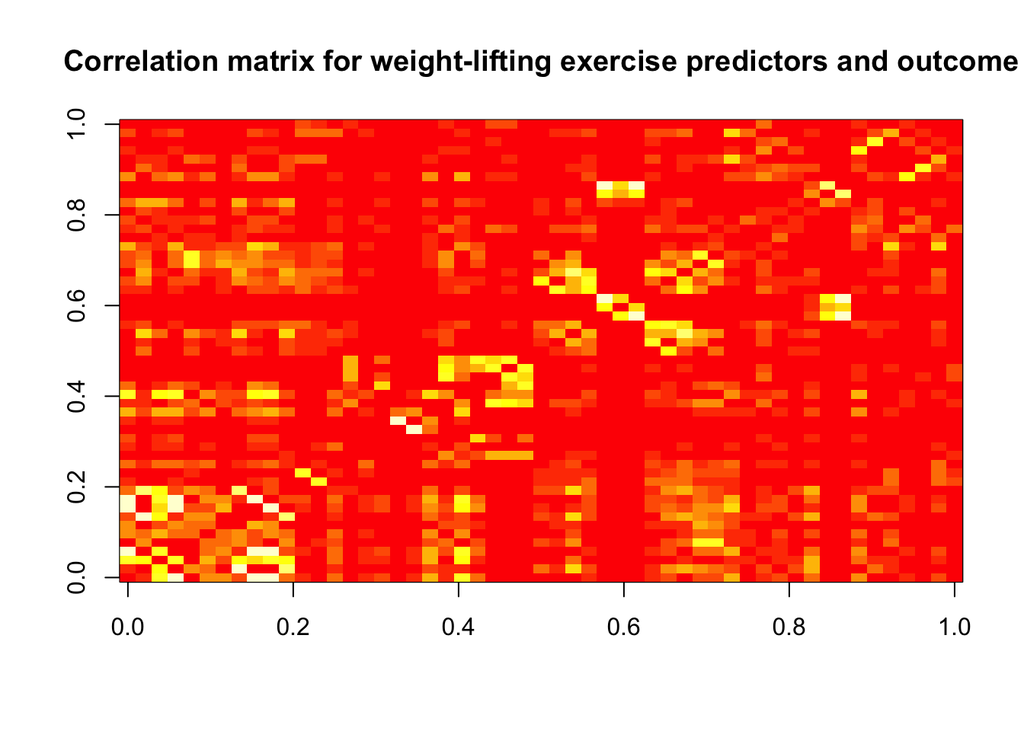

The top row visually indicates the correlation of all predictors with “classe”. There are 15 predictors that are relatively highly correlated with “classe”, with correlation exceeding 0.1. Next, we examine the relationship among the predictors, to see if any further dimension reduction could take place.

```
##              row col
## magnet_arm_x   6   5
## accel_arm_x    5   6
## magnet_arm_z   8   7
## magnet_arm_y   7   8
```

Out of the subset of 15 predictors, “accel_arm_x” is correlated to “magnet_arm_x”; and “magnet_arm_y” is correlated to “magnet_arm_z”. The presence of highly correlated predictors indicate Principal Component Analysis could potentially be used to build a better model.

### Build model

The training data is spliced into 5 folds for cross-validation. To each of the validation sets, 4 models are built using:

1. Decision Tree analysis applied to all predictor variables
2. Decision Tree analysis applied to the subset of predictors whose correlation with “classe” is higher than 0.1
3. Decision Tree analysis applied to all variables, with Principal Component Analysis
4. Decision Tree analysis applied to the subset of predictors whose correlation with “classe” is higher than 0.1, further taking out the predictors “accel_arm_x” and “magnet_arm_y”

Here’re the prediction accuracies (True Positives and True Negatives predicted) for each of the 5 holdout sets:

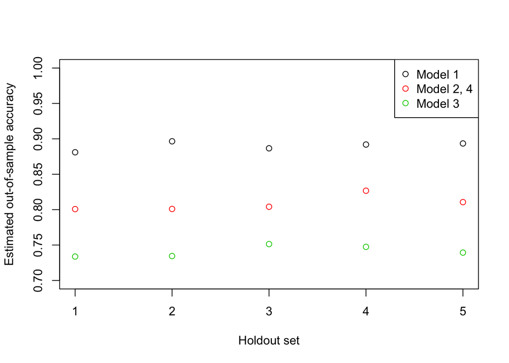

The average holdout set prediction accuracies for each of the models are:  
1. **Model 1**: 0.8899201  
2. **Model 2**: 0.8086338  
3. **Model 3**: 0.7412597  
4. **Model 4**: 0.8086338

The best accuracy is provided by Model 1, which takes into consideration of all the predictors in the dataset. This shows that, despite the fact that some of the predictors are not directly correlated with the outcome “classe”, their interaction with other predictors cannot be ignored. Therefore, *Model 1* is chosen and applied once on the test dataset.